# Sedimentation Monitoring

Ross Cunning

2026-04-29

```r
library(tidyverse)
library(readxl)
library(janitor)
library(lubridate)

project_dir <- if (basename(getwd()) == "code") dirname(getwd()) else getwd()
knitr::opts_knit$set(root.dir = project_dir)
```

## Import

```r
sediment_dir <- "data/sedimentation_monitoring"

gps_file <- file.path(sediment_dir, "PE_SB_Station_Transect_GPS.xlsx")

sediment_files <- list.files(
  sediment_dir,
  pattern = "xlsx$",
  recursive = TRUE,
  full.names = TRUE
) %>%
  discard(~ basename(.x) == basename(gps_file))
```

```r
excel_date <- function(x) {
  if (inherits(x, "Date")) return(x)
  if (inherits(x, "POSIXt")) return(as.Date(x))

  suppressWarnings(as.Date(as.numeric(x), origin = "1899-12-30"))
}

survey_number <- function(x) {
  if_else(
    x == "Baseline",
    0L,
    suppressWarnings(as.integer(str_extract(x, "\\d+")))
  )
}

normalize_transect_id <- function(x) {
  x %>%
    str_squish() %>%
    str_replace_all("\\s+", "_")
}

model_sedimentation_class <- function(transect) {
  case_when(
    transect %in% c("ST22", "ST31") ~ "1.0 cm predicted (dashed red)",
    transect %in% c("ST28", "ST5") ~ "1.5 mm predicted (solid red)",
    TRUE ~ "0 cm predicted (outside)"
  ) %>%
    factor(
      levels = c(
        "1.0 cm predicted (dashed red)",
        "1.5 mm predicted (solid red)",
        "0 cm predicted (outside)"
      ),
      ordered = TRUE
    )
}

model_sedimentation_predictions <- tibble(
  model_sedimentation_class = factor(
    c(
      "1.0 cm predicted (dashed red)",
      "1.5 mm predicted (solid red)",
      "0 cm predicted (outside)"
    ),
    levels = c(
      "1.0 cm predicted (dashed red)",
      "1.5 mm predicted (solid red)",
      "0 cm predicted (outside)"
    ),
    ordered = TRUE
  ),
  predicted_total_sedimentation_cm = c(1, 0.15, 0)
)

threshold_class <- function(x) {
  case_when(
    is.na(x) ~ NA_character_,
    x > 10 ~ ">10 cm",
    x > 5 ~ "5-10 cm",
    x > 1 ~ "1-5 cm",
    x > 0.5 ~ ">5 mm to 1 cm",
    x > 0.15 ~ ">1.5 to 5 mm",
    x >= 0 ~ "0 to 1.5 mm",
    TRUE ~ "below baseline"
  ) %>%
    factor(
      levels = c(
        "below baseline",
        "0 to 1.5 mm",
        ">1.5 to 5 mm",
        ">5 mm to 1 cm",
        "1-5 cm",
        "5-10 cm",
        ">10 cm"
      )
    )
}

read_sediment_raw <- function(path) {
  read_excel(path, sheet = "SedimentDepth_RawData", guess_max = 20000) %>%
    clean_names() %>%
    mutate(
      source_file = path,
      source_file_name = basename(path),
      source_modified = file.info(path)$mtime,
      monitoring_phase = case_when(
        str_detect(path, "1_Pre-Construction") ~ "pre_construction",
        str_detect(path, "2_During-Construction") ~ "during_construction",
        TRUE ~ "unknown"
      ),
      monitoring_type = case_when(
        str_detect(path, "Weekly Monitoring") ~ "weekly",
        str_detect(path, "Exceedance Triggered Monitoring") ~ "exceedance_triggered",
        TRUE ~ "compiled"
      ),
      date = excel_date(date),
      survey = str_squish(survey),
      survey_n = survey_number(survey),
      transect_type = str_squish(transect_type),
      transect = normalize_transect_id(transect),
      model_sedimentation_class = model_sedimentation_class(transect),
      meter = as.integer(meter),
      expected_permanent_length_m = case_when(
        transect_type == "Permanent" & transect %in% c("ST1", "ST38") ~ 150L,
        transect_type == "Permanent" ~ 50L,
        TRUE ~ NA_integer_
      ),
      across(starts_with("sed_depth_cm_"), as.numeric)
    )
}
```

## GPS Lookup

```r
hardbottom_gps <- read_excel(gps_file, sheet = "Hardbottom") %>%
  clean_names() %>%
  transmute(
    habitat = "hardbottom",
    transect = normalize_transect_id(str_remove(station_transect_id, "\\s+\\d+m$")),
    meter = as.integer(str_extract(station_transect_id, "\\d+(?=m$)")),
    gps_note = notes,
    lat_dd,
    lon_dd
  ) %>%
  filter(!is.na(transect), !is.na(meter))

seagrass_gps <- read_excel(gps_file, sheet = "Seagrass") %>%
  clean_names() %>%
  transmute(
    habitat = "seagrass",
    transect = normalize_transect_id(name),
    meter = NA_integer_,
    gps_note = location,
    lat_dd,
    lon_dd
  )

transect_meter_gps <- hardbottom_gps %>%
  filter(n() > 1, .by = transect) %>%
  arrange(transect, meter) %>%
  group_by(transect) %>%
  group_modify(~ {
    meter_seq <- seq(min(.x$meter), max(.x$meter))

    tibble(
      meter = meter_seq,
      lat_dd = approx(.x$meter, .x$lat_dd, xout = meter_seq, rule = 2)$y,
      lon_dd = approx(.x$meter, .x$lon_dd, xout = meter_seq, rule = 2)$y
    )
  }) %>%
  ungroup()
```

## Raw Sediment Data

The monitoring workbooks are cumulative, so later files repeat earlier surveys. After reading all workbooks, this keeps the most recent source for each survey/transect/meter record while retaining source metadata for traceability.

```r
sediment_raw_sources <- map_dfr(sediment_files, read_sediment_raw) %>%
  mutate(
    source_max_survey_n = max(survey_n, na.rm = TRUE),
    n_replicates_present = rowSums(!is.na(pick(starts_with("sed_depth_cm_")))),
    .by = source_file
  )

sediment_raw <- sediment_raw_sources %>%
  arrange(desc(source_max_survey_n), desc(source_modified), source_file_name) %>%
  distinct(
    date,
    survey,
    survey_n,
    transect_type,
    transect,
    meter,
    sed_depth_cm_1,
    sed_depth_cm_2,
    sed_depth_cm_3,
    .keep_all = TRUE
  ) %>%
  arrange(survey_n, transect, meter)

sediment_replicates <- sediment_raw %>%
  pivot_longer(
    starts_with("sed_depth_cm_"),
    names_to = "replicate",
    values_to = "sediment_depth_cm",
    values_drop_na = TRUE
  ) %>%
  mutate(
    replicate = as.integer(str_extract(replicate, "\\d+$")),
    sediment_depth_class = threshold_class(sediment_depth_cm)
  ) %>%
  left_join(transect_meter_gps, by = c("transect", "meter"))
```

## Baseline Differences

Sedimentation impact is defined in the Biological Monitoring Plan as an increase in mean sediment depth of 1 cm or more above mean baseline sediment depth. This chunk creates both raw replicate-level deltas and meter-level mean deltas so individual high measurements remain visible before any transect averaging.

```r
baseline_by_meter <- sediment_raw %>%
  filter(survey == "Baseline") %>%
  transmute(
    transect_type,
    transect,
    meter,
    baseline_mean_cm = rowMeans(
      pick(starts_with("sed_depth_cm_")),
      na.rm = TRUE
    ),
    baseline_max_cm = do.call(
      pmax,
      c(pick(starts_with("sed_depth_cm_")), list(na.rm = TRUE))
    )
  )

sediment_replicates_processed <- sediment_replicates %>%
  left_join(
    baseline_by_meter,
    by = c("transect_type", "transect", "meter")
  ) %>%
  mutate(
    sediment_delta_from_baseline_cm = sediment_depth_cm - baseline_mean_cm,
    sediment_delta_class = threshold_class(sediment_delta_from_baseline_cm),
    raw_gt_1cm_above_baseline = sediment_delta_from_baseline_cm >= 1
  )

sediment_meter_processed <- sediment_raw %>%
  mutate(
    mean_sediment_depth_cm = rowMeans(
      pick(starts_with("sed_depth_cm_")),
      na.rm = TRUE
    ),
    max_sediment_depth_cm = do.call(
      pmax,
      c(pick(starts_with("sed_depth_cm_")), list(na.rm = TRUE))
    ),
    n_replicates = rowSums(!is.na(pick(starts_with("sed_depth_cm_"))))
  ) %>%
  select(
    date,
    survey,
    survey_n,
    transect_type,
    transect,
    model_sedimentation_class,
    meter,
    expected_permanent_length_m,
    mean_sediment_depth_cm,
    max_sediment_depth_cm,
    n_replicates,
    monitoring_phase,
    monitoring_type,
    source_file,
    source_file_name
  ) %>%
  left_join(baseline_by_meter, by = c("transect_type", "transect", "meter")) %>%
  left_join(transect_meter_gps, by = c("transect", "meter")) %>%
  mutate(
    mean_delta_from_baseline_cm = mean_sediment_depth_cm - baseline_mean_cm,
    max_delta_from_baseline_cm = max_sediment_depth_cm - baseline_mean_cm,
    mean_delta_class = threshold_class(mean_delta_from_baseline_cm),
    max_delta_class = threshold_class(max_delta_from_baseline_cm),
    sedimentation_impact = mean_delta_from_baseline_cm >= 1,
    main_50m_segment = transect %in% c("ST1", "ST38") & between(meter, 0, 50)
  )
```

## Transect Summaries

```r
sediment_transect_processed <- sediment_meter_processed %>%
  summarize(
    n_meters = n(),
    transect_mean_depth_cm = mean(mean_sediment_depth_cm, na.rm = TRUE),
    transect_mean_baseline_cm = mean(baseline_mean_cm, na.rm = TRUE),
    transect_mean_delta_cm = transect_mean_depth_cm - transect_mean_baseline_cm,
    max_meter_mean_delta_cm = max(mean_delta_from_baseline_cm, na.rm = TRUE),
    max_raw_delta_cm = max(max_delta_from_baseline_cm, na.rm = TRUE),
    n_meters_mean_gt_1cm = sum(mean_delta_from_baseline_cm >= 1, na.rm = TRUE),
    pct_meters_mean_gt_1cm = n_meters_mean_gt_1cm / n_meters,
    sedimentation_impact = transect_mean_delta_cm >= 1,
    main_50m_sedimentation_impact = any(
      main_50m_segment & mean_delta_from_baseline_cm >= 1,
      na.rm = TRUE
    ),
    .by = c(
      date,
      survey,
      survey_n,
      transect_type,
      transect,
      model_sedimentation_class
    )
  ) %>%
  arrange(survey_n, model_sedimentation_class, transect)
```

## Quick Visual Checks

The raw sediment sheets contain 19 transects total. Six adjacent transects are Baseline-only, so construction-only plots show the 13 permanent transects.

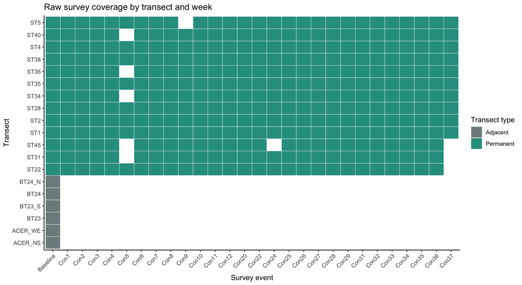

```r
sediment_raw %>%
  distinct(transect_type, transect, survey_n, survey) %>%
  mutate(
    transect = fct_reorder(transect, survey_n, .fun = max),
    survey = fct_reorder(survey, survey_n)
  ) %>%
  ggplot(aes(x = survey, y = transect, fill = transect_type)) +
  geom_tile(color = "white", linewidth = 0.2) +
  scale_fill_manual(
    values = c("Adjacent" = "#7f8c8d", "Permanent" = "#2a9d8f")
  ) +
  labs(
    x = "Survey event",
    y = "Transect",
    fill = "Transect type",
    title = "Raw survey coverage by transect and week"
  ) +
  theme_classic() +
  theme(axis.text.x = element_text(angle = 45, hjust = 1))
```

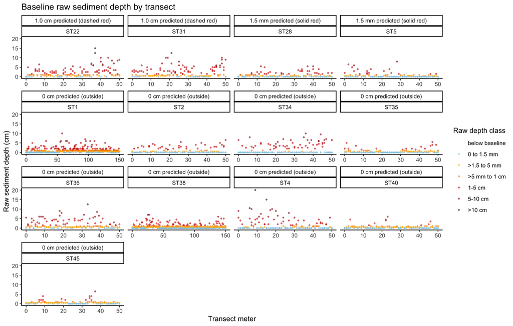

```r
sediment_replicates %>%
  filter(survey == "Baseline", transect_type == "Permanent") %>%
  ggplot(aes(x = meter, y = sediment_depth_cm)) +
  geom_point(aes(color = sediment_depth_class), alpha = 0.55, size = 0.7) +
  facet_wrap(~ model_sedimentation_class + transect, scales = "free_x") +
  scale_color_manual(
    values = c(
      "below baseline" = "grey90",
      "0 to 1.5 mm" = "#8ecae6",
      ">1.5 to 5 mm" = "#ffb703",
      ">5 mm to 1 cm" = "#fb8500",
      "1-5 cm" = "#d00000",
      "5-10 cm" = "#9d0208",
      ">10 cm" = "#370617"
    ),
    drop = FALSE
  ) +
  labs(
    x = "Transect meter",
    y = "Raw sediment depth (cm)",
    color = "Raw depth class",
    title = "Baseline raw sediment depth by transect"
  ) +
  theme_classic()
```

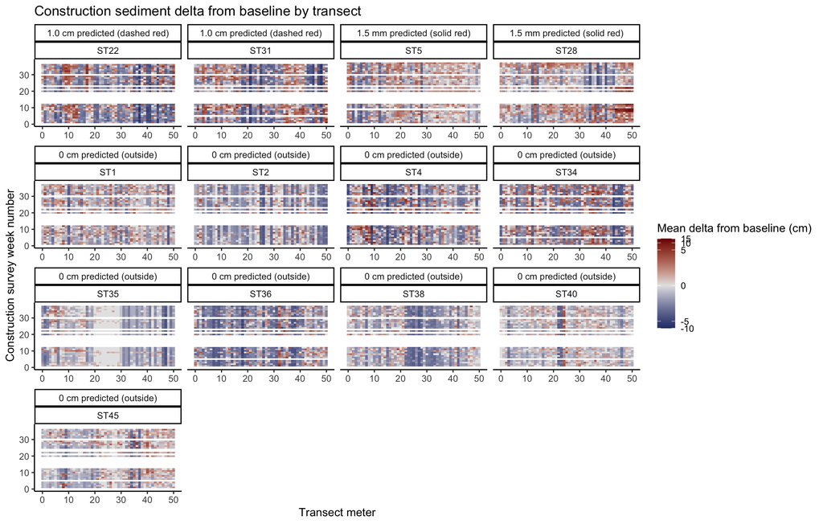

```r
sediment_meter_processed %>%
  filter(survey != "Baseline", transect_type == "Permanent") %>%
  mutate(
    plot_max_meter_m = if_else(
      transect %in% c("ST1", "ST38"),
      50L,
      expected_permanent_length_m
    )
  ) %>%
  {
    meter_grid <- distinct(
      .,
      date,
      survey,
      survey_n,
      transect_type,
      transect,
      model_sedimentation_class,
      expected_permanent_length_m,
      plot_max_meter_m
    ) %>%
      mutate(meter = map(plot_max_meter_m, ~ seq(0L, .x))) %>%
      unnest(meter)

    right_join(
      .,
      meter_grid,
      by = c(
        "date",
        "survey",
        "survey_n",
        "transect_type",
        "transect",
        "model_sedimentation_class",
        "expected_permanent_length_m",
        "plot_max_meter_m",
        "meter"
      )
    )
  } %>%
  mutate(
    transect = fct_reorder(
      transect,
      as.integer(model_sedimentation_class) * 1000 + parse_number(transect),
      .fun = min
    )
  ) %>%
  ggplot(aes(x = meter, y = survey_n, fill = mean_delta_from_baseline_cm)) +
  geom_tile() +
  facet_wrap(~ model_sedimentation_class + transect, scales = "free_x") +
  scale_fill_gradient2(
    low = "#08306b",
    mid = "gray90",
    high = "#7f0000",
    midpoint = 0,
    trans = scales::pseudo_log_trans(sigma = 0.15),
    na.value = "grey95",
    name = "Mean delta from baseline (cm)"
  ) +
  labs(
    x = "Transect meter",
    y = "Construction survey week number",
    title = "Construction sediment delta from baseline by transect"
  ) +
  theme_classic()
```

## Reef-scale Construction Delta Summaries

```r
threshold_levels <- levels(threshold_class(0))
construction_reef_delta_grid <- sediment_meter_processed %>%
  filter(survey != "Baseline", transect_type == "Permanent") %>%
  mutate(
    analysis_max_meter_m = if_else(
      transect %in% c("ST1", "ST38"),
      50L,
      expected_permanent_length_m
    )
  ) %>%
  {
    meter_grid <- distinct(
      .,
      date,
      survey,
      survey_n,
      transect_type,
      transect,
      model_sedimentation_class,
      expected_permanent_length_m,
      analysis_max_meter_m
    ) %>%
      mutate(meter = map(analysis_max_meter_m, ~ seq(0L, .x))) %>%
      unnest(meter)

    right_join(
      .,
      meter_grid,
      by = c(
        "date",
        "survey",
        "survey_n",
        "transect_type",
        "transect",
        "model_sedimentation_class",
        "expected_permanent_length_m",
        "analysis_max_meter_m",
        "meter"
      )
    )
  } %>%
  mutate(
    mean_delta_class = factor(
      if_else(
        is.na(mean_delta_class),
        "unmeasured",
        as.character(mean_delta_class)
      ),
      levels = c(threshold_levels, "unmeasured")
    )
  )

reef_delta_denominators <- construction_reef_delta_grid %>%
  summarize(
    survey_start_date = min(date, na.rm = TRUE),
    survey_end_date = max(date, na.rm = TRUE),
    survey_dates = paste(sort(unique(date)), collapse = ", "),
    expected_meter_positions = n(),
    measured_meter_positions = sum(!is.na(mean_delta_from_baseline_cm)),
    pct_meter_positions_measured = measured_meter_positions / expected_meter_positions,
    .by = c(survey, survey_n, model_sedimentation_class)
  )

reef_delta_summary_by_week_class <- construction_reef_delta_grid %>%
  filter(!is.na(mean_delta_from_baseline_cm)) %>%
  summarize(
    mean_delta_cm = mean(mean_delta_from_baseline_cm),
    p01_delta_cm = quantile(mean_delta_from_baseline_cm, 0.01),
    p10_delta_cm = quantile(mean_delta_from_baseline_cm, 0.10),
    p25_delta_cm = quantile(mean_delta_from_baseline_cm, 0.25),
    median_delta_cm = median(mean_delta_from_baseline_cm),
    p75_delta_cm = quantile(mean_delta_from_baseline_cm, 0.75),
    p90_delta_cm = quantile(mean_delta_from_baseline_cm, 0.90),
    p99_delta_cm = quantile(mean_delta_from_baseline_cm, 0.99),
    min_delta_cm = min(mean_delta_from_baseline_cm),
    max_delta_cm = max(mean_delta_from_baseline_cm),
    range_delta_cm = max_delta_cm - min_delta_cm,
    .by = c(survey, survey_n, model_sedimentation_class)
  ) %>%
  left_join(
    reef_delta_denominators,
    by = c("survey", "survey_n", "model_sedimentation_class")
  ) %>%
  arrange(survey_n, model_sedimentation_class)
```

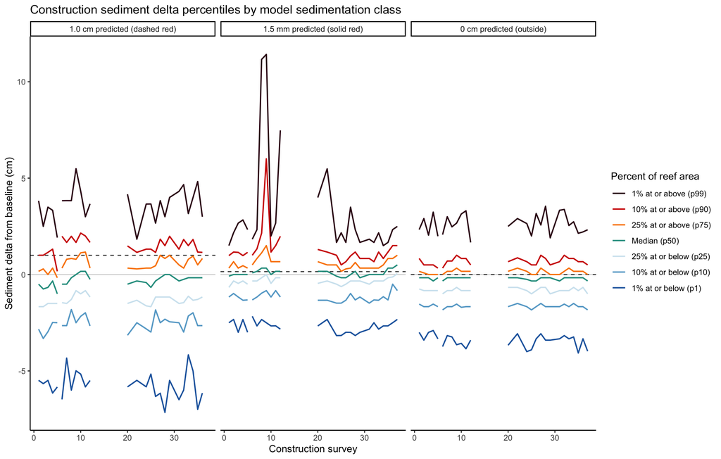

```r
reef_delta_summary_plot <- reef_delta_summary_by_week_class %>%
  select(
    survey_start_date,
    survey_n,
    model_sedimentation_class,
    p01_delta_cm,
    p10_delta_cm,
    p25_delta_cm,
    median_delta_cm,
    p75_delta_cm,
    p90_delta_cm,
    p99_delta_cm
  ) %>%
  pivot_longer(
    ends_with("_delta_cm"),
    names_to = "delta_percentile",
    values_to = "delta_cm"
  ) %>%
  mutate(
    delta_percentile = recode(
      delta_percentile,
      p01_delta_cm = "1% at or below (p1)",
      p10_delta_cm = "10% at or below (p10)",
      p25_delta_cm = "25% at or below (p25)",
      median_delta_cm = "Median (p50)",
      p75_delta_cm = "25% at or above (p75)",
      p90_delta_cm = "10% at or above (p90)",
      p99_delta_cm = "1% at or above (p99)"
    ),
    delta_percentile = factor(
      delta_percentile,
      levels = c(
        "1% at or below (p1)",
        "10% at or below (p10)",
        "25% at or below (p25)",
        "Median (p50)",
        "25% at or above (p75)",
        "10% at or above (p90)",
        "1% at or above (p99)"
      )
    )
  ) %>%
  arrange(model_sedimentation_class, delta_percentile, survey_start_date) %>%
  mutate(
    monitoring_gap_days = as.numeric(survey_start_date - lag(survey_start_date)),
    plot_segment = cumsum(coalesce(monitoring_gap_days > 14, FALSE)),
    .by = c(model_sedimentation_class, delta_percentile)
  ) %>%
  ggplot(aes(x = survey_n, y = delta_cm, color = delta_percentile)) +
  geom_hline(yintercept = 0, color = "grey75", linewidth = 0.3) +
  geom_hline(
    data = model_sedimentation_predictions,
    aes(yintercept = predicted_total_sedimentation_cm),
    linetype = "dashed",
    color = "black",
    linewidth = 0.4
  ) +
  geom_line(aes(group = interaction(delta_percentile, plot_segment)), linewidth = 0.7) +
  facet_wrap(~ model_sedimentation_class) +
  scale_color_manual(
    values = c(
      "1% at or below (p1)" = "#2166ac",
      "10% at or below (p10)" = "#67a9cf",
      "25% at or below (p25)" = "#d1e5f0",
      "Median (p50)" = "#2a9d8f",
      "25% at or above (p75)" = "#fb8500",
      "10% at or above (p90)" = "#d00000",
      "1% at or above (p99)" = "#370617"
    ),
    guide = guide_legend(reverse = TRUE)
  ) +
  labs(
    x = "Construction survey",
    y = "Sediment delta from baseline (cm)",
    color = "Percent of reef area",
    title = "Construction sediment delta percentiles by model sedimentation class"
  ) +
  theme_classic()

reef_delta_summary_plot
```

## Net Positive Exceedance Tests

These tests compare the measured area with positive sedimentation above a threshold to the measured area with negative sedimentation below the equivalent threshold. The `outside` class is outside the model-predicted sedimentation footprint, but it is not treated as an unimpacted reference because it may still receive dredging-related sediment. The bootstrap resamples transects within each survey and model sedimentation class, so confidence intervals reflect transect-level clustering rather than treating every meter as fully independent.

Interpretation: this is an area-balance screening metric. Positive values mean more measured reef area exceeded a positive sedimentation threshold than fell below the same magnitude negative threshold. It is best for asking whether sediment accumulation above specific, interpretable thresholds is spatially more common than equivalent sediment loss.

```r
set.seed(20260429)

net_exceedance_bootstrap_n <- 100

net_exceedance_thresholds <- tibble(
  threshold_cm = c(0.15, 0.5, 1),
  threshold_label = factor(
    c("0.15 cm (1.5 mm)", "0.5 cm", "1.0 cm"),
    levels = c("0.15 cm (1.5 mm)", "0.5 cm", "1.0 cm")
  )
)

bootstrap_net_exceedance <- function(data, threshold_cm, n_boot) {
  transects <- sort(unique(data$transect))

  map_dfr(seq_len(n_boot), function(boot_i) {
    boot_delta <- sample(transects, length(transects), replace = TRUE) %>%
      map(~ data$mean_delta_from_baseline_cm[data$transect == .x]) %>%
      list_c()

    tibble(
      boot_i = boot_i,
      positive_area = mean(boot_delta >= threshold_cm),
      negative_area = mean(boot_delta <= -threshold_cm),
      net_positive_area = positive_area - negative_area
    )
  })
}

construction_measured_deltas <- construction_reef_delta_grid %>%
  filter(!is.na(mean_delta_from_baseline_cm))

net_exceedance_observed <- construction_measured_deltas %>%
  cross_join(net_exceedance_thresholds) %>%
  summarize(
    survey_start_date = min(date, na.rm = TRUE),
    survey_end_date = max(date, na.rm = TRUE),
    survey_dates = paste(sort(unique(date)), collapse = ", "),
    measured_meter_positions = n(),
    n_transects = n_distinct(transect),
    positive_meter_positions = sum(mean_delta_from_baseline_cm >= threshold_cm),
    negative_meter_positions = sum(mean_delta_from_baseline_cm <= -threshold_cm),
    positive_area = positive_meter_positions / measured_meter_positions,
    negative_area = negative_meter_positions / measured_meter_positions,
    net_positive_area = positive_area - negative_area,
    .by = c(
      survey,
      survey_n,
      model_sedimentation_class,
      threshold_cm,
      threshold_label
    )
  )

net_exceedance_bootstrap <- construction_measured_deltas %>%
  cross_join(net_exceedance_thresholds) %>%
  group_by(survey, survey_n, model_sedimentation_class, threshold_cm, threshold_label) %>%
  group_modify(
    ~ bootstrap_net_exceedance(
      .x,
      threshold_cm = .y$threshold_cm,
      n_boot = net_exceedance_bootstrap_n
    )
  ) %>%
  ungroup()

net_exceedance_ci <- net_exceedance_bootstrap %>%
  summarize(
    net_positive_area_lcl = quantile(net_positive_area, 0.025),
    net_positive_area_ucl = quantile(net_positive_area, 0.975),
    .by = c(
      survey,
      survey_n,
      model_sedimentation_class,
      threshold_cm,
      threshold_label
    )
  )

net_exceedance_by_week_class <- net_exceedance_observed %>%
  left_join(
    net_exceedance_ci,
    by = c(
      "survey",
      "survey_n",
      "model_sedimentation_class",
      "threshold_cm",
      "threshold_label"
    )
  ) %>%
  mutate(
    ci_note = if_else(
      n_transects < 3,
      "CI not estimated: fewer than 3 transects",
      "Transect bootstrap CI"
    ),
    across(
      c(net_positive_area_lcl, net_positive_area_ucl),
      ~ if_else(n_transects < 3, NA_real_, .x)
    ),
    evidence_positive_asymmetry = net_positive_area_lcl > 0
  ) %>%
  arrange(survey_n, model_sedimentation_class, threshold_cm)
```

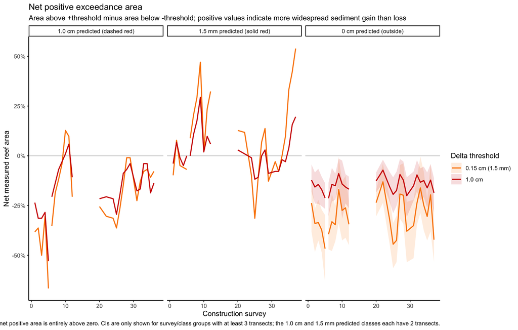

```r
net_exceedance_threshold_plot_data <- net_exceedance_by_week_class %>%
  filter(threshold_cm %in% c(0.15, 1.0)) %>%
  arrange(model_sedimentation_class, threshold_label, survey_start_date) %>%
  mutate(
    monitoring_gap_days = as.numeric(survey_start_date - lag(survey_start_date)),
    plot_segment = cumsum(coalesce(monitoring_gap_days > 14, FALSE)),
    .by = c(model_sedimentation_class, threshold_label)
  )

positive_asymmetry_annotations <- net_exceedance_threshold_plot_data %>%
  filter(evidence_positive_asymmetry) %>%
  mutate(annotation_y = net_positive_area_ucl)

net_exceedance_threshold_plot <- net_exceedance_threshold_plot_data %>%
  ggplot(aes(x = survey_n, y = net_positive_area, color = threshold_label)) +
  geom_hline(yintercept = 0, color = "grey70", linewidth = 0.3) +
  geom_ribbon(
    data = ~ filter(.x, !is.na(net_positive_area_lcl), !is.na(net_positive_area_ucl)),
    aes(
      ymin = net_positive_area_lcl,
      ymax = net_positive_area_ucl,
      fill = threshold_label,
      group = interaction(threshold_label, plot_segment)
    ),
    alpha = 0.14,
    color = NA
  ) +
  geom_line(
    aes(group = interaction(threshold_label, plot_segment)),
    linewidth = 0.8
  ) +
  geom_text(
    data = positive_asymmetry_annotations,
    aes(x = survey_n, y = annotation_y, label = "*"),
    color = "black",
    vjust = -0.35,
    size = 4,
    show.legend = FALSE
  ) +
  facet_wrap(~ model_sedimentation_class) +
  scale_y_continuous(labels = scales::percent) +
  scale_color_manual(
    values = c(
      "0.15 cm (1.5 mm)" = "#fb8500",
      "1.0 cm" = "#d00000"
    )
  ) +
  scale_fill_manual(
    values = c(
      "0.15 cm (1.5 mm)" = "#fb8500",
      "1.0 cm" = "#d00000"
    )
  ) +
  labs(
    x = "Construction survey",
    y = "Net measured reef area",
    color = "Delta threshold",
    fill = "Delta threshold",
    title = "Net positive exceedance area",
    subtitle = paste(
      "Area above +threshold minus area below -threshold;",
      "positive values indicate more widespread sediment gain than loss"
    ),
    caption = paste(
      "* Bootstrap CI for net positive area is entirely above zero.",
      "CIs are only shown for survey/class groups with at least 3 transects;",
      "the 1.0 cm and 1.5 mm predicted classes each have 2 transects."
    )
  ) +
  theme_classic()

net_exceedance_threshold_plot
```

## Focused Attribution Analyses

The net-positive exceedance summaries are useful screening tools, but they are not a complete attribution analysis. The following sections explore complementary ways to ask whether construction-period deltas show directional sediment accumulation. These are deliberately exploratory: each method answers a slightly different question and has different assumptions.

The net-positive exceedance plot asks an area question: how much measured reef area is above a positive threshold after subtracting area below the equivalent negative threshold? The week-specific tail-balance plot below asks a different magnitude question: when sediment gains occur in the upper tail of the weekly distribution, are those gains larger than the corresponding sediment-loss tail?

### Week-specific Tail-balance Tests

This approach keeps construction survey as a time series while explicitly accounting for opposite negative deltas. For each survey and predicted sedimentation class, it compares matched positive and negative tails: `p75 - abs(p25)`, `p90 - abs(p10)`, and `p95 - abs(p05)`. Positive values mean the sediment-gain tail is larger than the sediment-loss tail for that week. The bootstrap resamples transects, and confidence intervals are not estimated when fewer than three transects are available in a survey/class group.

Interpretation: this is a magnitude-asymmetry diagnostic. It is less directly spatial than the net-exceedance plot, but it can show whether the largest positive sediment deltas are more extreme than the largest negative deltas, even when the affected area is limited.

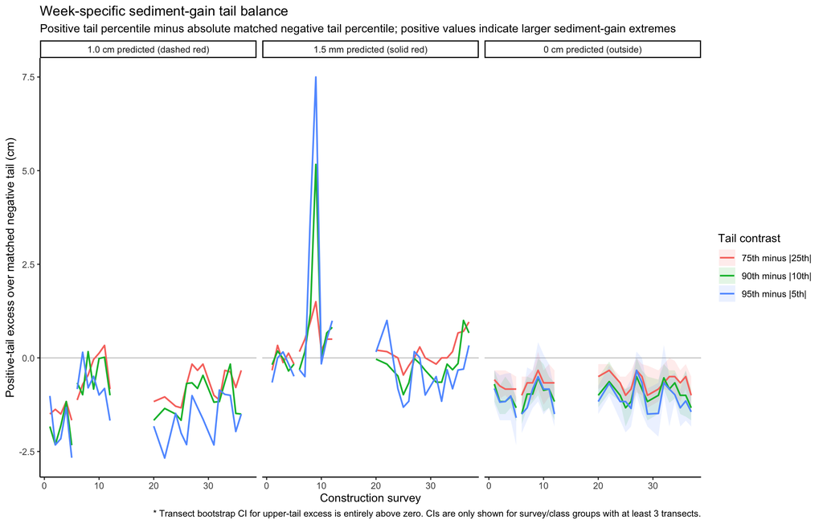

```r
week_tail_balance_bootstrap_n <- 100

summarize_tail_balance <- function(delta) {
  delta_quantiles <- quantile(
    delta,
    probs = c(0.05, 0.10, 0.25, 0.75, 0.90, 0.95),
    names = TRUE
  )

  tibble(
    tail_contrast = factor(
      c("75th minus |25th|", "90th minus |10th|", "95th minus |5th|"),
      levels = c("75th minus |25th|", "90th minus |10th|", "95th minus |5th|")
    ),
    lower_percentile = c(0.25, 0.10, 0.05),
    upper_percentile = c(0.75, 0.90, 0.95),
    lower_delta_cm = as.numeric(delta_quantiles[c("25%", "10%", "5%")]),
    upper_delta_cm = as.numeric(delta_quantiles[c("75%", "90%", "95%")]),
    upper_tail_excess_cm = upper_delta_cm - abs(lower_delta_cm)
  )
}

bootstrap_tail_balance <- function(data, n_boot) {
  transects <- sort(unique(data$transect))

  map_dfr(seq_len(n_boot), function(boot_i) {
    boot_delta <- sample(transects, length(transects), replace = TRUE) %>%
      map(~ data$mean_delta_from_baseline_cm[data$transect == .x]) %>%
      list_c()

    summarize_tail_balance(boot_delta) %>%
      mutate(boot_i = boot_i, .before = 1)
  })
}

week_tail_balance_observed <- construction_measured_deltas %>%
  summarize(
    survey_start_date = min(date, na.rm = TRUE),
    survey_end_date = max(date, na.rm = TRUE),
    survey_dates = paste(sort(unique(date)), collapse = ", "),
    measured_meter_positions = n(),
    n_transects = n_distinct(transect),
    tail_balance = list(summarize_tail_balance(mean_delta_from_baseline_cm)),
    .by = c(survey, survey_n, model_sedimentation_class)
  ) %>%
  unnest(tail_balance)

week_tail_balance_bootstrap <- construction_measured_deltas %>%
  group_by(survey, survey_n, model_sedimentation_class) %>%
  group_modify(~ bootstrap_tail_balance(.x, week_tail_balance_bootstrap_n)) %>%
  ungroup()

week_tail_balance_ci <- week_tail_balance_bootstrap %>%
  summarize(
    upper_tail_excess_lcl = quantile(upper_tail_excess_cm, 0.025),
    upper_tail_excess_ucl = quantile(upper_tail_excess_cm, 0.975),
    .by = c(survey, survey_n, model_sedimentation_class, tail_contrast)
  )

week_tail_balance_tests <- week_tail_balance_observed %>%
  left_join(
    week_tail_balance_ci,
    by = c("survey", "survey_n", "model_sedimentation_class", "tail_contrast")
  ) %>%
  mutate(
    ci_note = if_else(
      n_transects < 3,
      "CI not estimated: fewer than 3 transects",
      "Transect bootstrap CI"
    ),
    across(
      c(upper_tail_excess_lcl, upper_tail_excess_ucl),
      ~ if_else(n_transects < 3, NA_real_, .x)
    ),
    evidence_positive_tail_asymmetry = upper_tail_excess_lcl > 0
  ) %>%
  arrange(survey_n, model_sedimentation_class, tail_contrast)

week_tail_balance_plot_data <- week_tail_balance_tests %>%
  arrange(model_sedimentation_class, tail_contrast, survey_start_date) %>%
  mutate(
    monitoring_gap_days = as.numeric(survey_start_date - lag(survey_start_date)),
    plot_segment = cumsum(coalesce(monitoring_gap_days > 14, FALSE)),
    .by = c(model_sedimentation_class, tail_contrast)
  )

week_tail_balance_annotations <- week_tail_balance_plot_data %>%
  filter(evidence_positive_tail_asymmetry) %>%
  mutate(annotation_y = upper_tail_excess_ucl)

week_tail_balance_plot <- week_tail_balance_plot_data %>%
  ggplot(aes(x = survey_n, y = upper_tail_excess_cm, color = tail_contrast)) +
  geom_hline(yintercept = 0, color = "grey70", linewidth = 0.3) +
  geom_ribbon(
    data = ~ filter(.x, !is.na(upper_tail_excess_lcl), !is.na(upper_tail_excess_ucl)),
    aes(
      ymin = upper_tail_excess_lcl,
      ymax = upper_tail_excess_ucl,
      fill = tail_contrast,
      group = interaction(tail_contrast, plot_segment)
    ),
    alpha = 0.12,
    color = NA
  ) +
  geom_line(
    aes(group = interaction(tail_contrast, plot_segment)),
    linewidth = 0.75
  ) +
  geom_text(
    data = week_tail_balance_annotations,
    aes(x = survey_n, y = annotation_y, label = "*"),
    color = "black",
    vjust = -0.35,
    size = 4,
    show.legend = FALSE
  ) +
  facet_wrap(~ model_sedimentation_class) +
  labs(
    x = "Construction survey",
    y = "Positive-tail excess over matched negative tail (cm)",
    color = "Tail contrast",
    fill = "Tail contrast",
    title = "Week-specific sediment-gain tail balance",
    subtitle = paste(
      "Positive tail percentile minus absolute matched negative tail percentile;",
      "positive values indicate larger sediment-gain extremes"
    ),
    caption = paste(
      "* Transect bootstrap CI for upper-tail excess is entirely above zero.",
      "CIs are only shown for survey/class groups with at least 3 transects."
    )
  ) +
  theme_classic()

week_tail_balance_plot
```

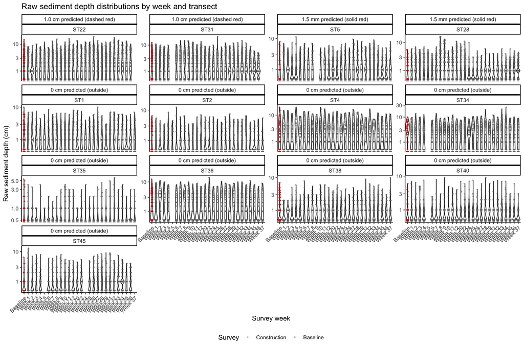

```r
sediment_replicates_processed %>%
  filter(transect_type == "Permanent") %>%
  mutate(
    survey_week = factor(
      survey_n,
      levels = sort(unique(survey_n)),
      labels = if_else(
        sort(unique(survey_n)) == 0,
        "Baseline",
        paste0("Week ", sort(unique(survey_n)))
      )
    ),
    transect = fct_reorder(
      transect,
      as.integer(model_sedimentation_class) * 1000 + readr::parse_number(transect),
      .fun = min
    )
  ) %>%
  ggplot(aes(x = survey_week, y = sediment_depth_cm)) +
  # geom_boxplot(
  #   outlier.shape = NA,
  #   fill = "grey85",
  #   color = "grey25",
  #   linewidth = 0.35
  # ) +
  geom_violin() +
  geom_jitter(
    aes(color = survey == "Baseline"),
    width = 0.18,
    height = 0,
    alpha = 0.35,
    size = 0.6
  ) +
  facet_wrap(~ model_sedimentation_class + transect, scales = "free_y") +
  scale_color_manual(
    values = c("FALSE" = "grey45", "TRUE" = "#d00000"),
    labels = c("Construction", "Baseline"),
    name = "Survey"
  ) +
  labs(
    x = "Survey week",
    y = "Raw sediment depth (cm)",
    title = "Raw sediment depth distributions by week and transect"
  ) +
  theme_classic() +
  theme(
    axis.text.x = element_text(angle = 45, hjust = 1),
    legend.position = "bottom"
  ) +
  scale_y_continuous(transform = "log10")
```

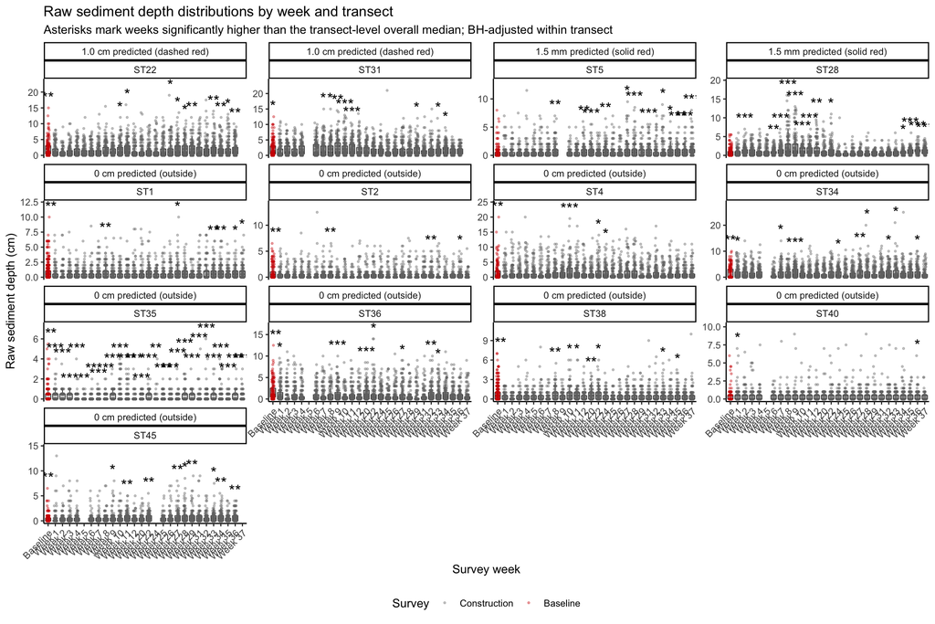

```r
plot_data <- sediment_replicates_processed %>%
  filter(transect_type == "Permanent") %>%
  mutate(
    survey_week = factor(
      survey_n,
      levels = sort(unique(survey_n)),
      labels = if_else(
        sort(unique(survey_n)) == 0,
        "Baseline",
        paste0("Week ", sort(unique(survey_n)))
      )
    ),
    transect = fct_reorder(
      transect,
      as.integer(model_sedimentation_class) * 1000 + readr::parse_number(transect),
      .fun = min
    )
  )

meter_week_depths <- plot_data %>%
  summarize(
    meter_week_mean_cm = mean(sediment_depth_cm, na.rm = TRUE),
    .by = c(
      transect_type,
      transect,
      model_sedimentation_class,
      survey_n,
      survey_week,
      meter
    )
  ) %>%
  mutate(
    transect_overall_median_cm = median(meter_week_mean_cm, na.rm = TRUE),
    .by = transect
  )

week_tests <- meter_week_depths %>%
  summarize(
    n_meters = sum(!is.na(meter_week_mean_cm)),
    p_value = {
      x <- meter_week_mean_cm[!is.na(meter_week_mean_cm)]
      mu <- first(transect_overall_median_cm)
      differences <- x - mu

      if (
        length(x) >= 3 &&
          is.finite(mu) &&
          n_distinct(differences[differences != 0], na.rm = TRUE) > 1
      ) {
        wilcox.test(
          x,
          mu = mu,
          alternative = "greater",
          exact = FALSE
        )$p.value
      } else {
        NA_real_
      }
    },
    .by = c(transect, model_sedimentation_class, survey_n, survey_week)
  ) %>%
  mutate(
    p_adj = p.adjust(p_value, method = "BH"),
    sig_label = case_when(
      p_adj <= 0.001 ~ "***",
      p_adj <= 0.01 ~ "**",
      p_adj <= 0.05 ~ "*",
      TRUE ~ NA_character_
    ),
    .by = transect
  )

annotation_data <- plot_data %>%
  summarize(
    week_max_cm = max(sediment_depth_cm, na.rm = TRUE),
    .by = c(transect, model_sedimentation_class, survey_week)
  ) %>%
  left_join(
    plot_data %>%
      summarize(
        panel_min_cm = min(sediment_depth_cm, na.rm = TRUE),
        panel_max_cm = max(sediment_depth_cm, na.rm = TRUE),
        .by = c(transect, model_sedimentation_class)
      ),
    by = c("transect", "model_sedimentation_class")
  ) %>%
  inner_join(
    filter(week_tests, !is.na(sig_label)),
    by = c("transect", "model_sedimentation_class", "survey_week")
  ) %>%
  mutate(
    y = week_max_cm + pmax(
      (panel_max_cm - panel_min_cm) * 0.08,
      panel_max_cm * 0.05,
      0.05
    )
  )

ggplot(plot_data, aes(x = survey_week, y = sediment_depth_cm)) +
  geom_boxplot(
    outlier.shape = NA,
    fill = "grey85",
    color = "grey25",
    linewidth = 0.35
  ) +
  geom_jitter(
    aes(color = survey == "Baseline"),
    width = 0.18,
    height = 0,
    alpha = 0.35,
    size = 0.6
  ) +
  geom_text(
    data = annotation_data,
    aes(x = survey_week, y = y, label = sig_label),
    inherit.aes = FALSE,
    size = 5,
    vjust = 0
  ) +
  facet_wrap(~ model_sedimentation_class + transect, scales = "free_y") +
  scale_color_manual(
    values = c("FALSE" = "grey45", "TRUE" = "#d00000"),
    labels = c("Construction", "Baseline"),
    name = "Survey"
  ) +
  scale_y_continuous(expand = expansion(mult = c(0.04, 0.18))) +
  labs(
    x = "Survey week",
    y = "Raw sediment depth (cm)",
    title = "Raw sediment depth distributions by week and transect",
    subtitle = "Asterisks mark weeks significantly higher than the transect-level overall median; BH-adjusted within transect"
  ) +
  theme_classic() +
  theme(
    axis.text.x = element_text(angle = 45, hjust = 1),
    legend.position = "bottom"
  )
```